# 嶺東科大-FinTech 金融科技課程

利用R語言-台灣南六企業股價k線及技術指標

楊永列 Yang Yung-Lieh

2017年2月16日

# 南六企業董事長黃清山-發揚嶺東科技大學母校精神拼出璀璨人生

嶺東科技大學創立超過半世紀，為台灣孕育眾多傑出人才，南六企業董事長黃清山就是其中的典範之一， 他不僅打造華人世界第一、亞洲第二大的不織布王國，更體現母校校訓「學以致用，誠以待人」， 持續勤學創新、不斷奉獻公益！ 國中畢業後，黃清山進入嶺東商專會計科就讀，印象最深刻的，就是母校優美田園的環境影響！ 「如同校歌的歌詞一樣，校園周邊真的就是『春色 景麗 平野 輕蔥 黎明挹秀氣 桃李吐青榮…』！ 當年大家都會到筏子溪釣魚，而我也在專四時，一面看著溪流，一面立下了將來創業的夢想！」他回想著當年的求學印象。 身教言教境教奠定創業基礎在學校就讀的五年時光中， 創辦人黎明與蔡亞萍夫妻的身影最讓黃清山難忘，「兩人生活儉樸與認真教學、待學生如子女的溫暖， 都是最佳的身教與言教，而學校的校訓『學以致用，誠以待人』，更是我一生遵奉的原則！」 在會計專業的學習上，黃清山深刻地記得，在成本會計的課堂後， 他仍有疑問，老師耐心傳授成本控管的心法，包括人力、良率、生產率、機械折舊、採構等成本細節， 奠定他未來經營工廠的數字概念，得以精準控制成本，逐漸成為業界知名的「拼王」! 創立南六企業 打造不織布王國 http://www.cw.com.tw/article/article.action?id=5080766.

## 第1步：R工作目錄指令

```r
getwd()
```

```
## [1] "D:/Fintech"
```

```r
setwd("D:/Fintech/")
getwd()
```

```
## [1] "D:/Fintech"
```

## 第2步：R使用quantmod套件指令

```r
library(quantmod)
```

## 第3步：R網路抓取Yahoo中南六企業股價資料

```r
getSymbols("6504.TW")
```

[output not shown]

```
## [1] "6504.TW"
```

```r
LTU6504<-get("6504.TW")
head(LTU6504)
```

```
##            6504.TW.Open 6504.TW.High 6504.TW.Low 6504.TW.Close
## 2007-12-31        27.00         27.5       26.04          27.5
## 2008-01-02        28.00         28.0       28.00          28.0
## 2008-01-03        28.50         30.2       28.50          30.2
## 2008-01-04        27.44         29.5       27.44          29.5
## 2008-01-07        27.00         29.0       27.00          29.0
## 2008-01-09        28.30         28.5       28.30          28.5
##            6504.TW.Volume 6504.TW.Adjusted
## 2007-12-31           5100          19.5697
## 2008-01-02           1200          19.9255
## 2008-01-03           6400          21.4911
## 2008-01-04           3800          20.9929
## 2008-01-07           3800          20.6371
## 2008-01-09           5100          20.2813
```

```r
tail(LTU6504)
```

```
##            6504.TW.Open 6504.TW.High 6504.TW.Low 6504.TW.Close
## 2017-02-08        155.0        155.5       154.0         155.0
## 2017-02-09        156.0        156.0       154.0         154.5
## 2017-02-10        156.0        157.0       154.5         154.5
## 2017-02-13        156.0        157.0       154.5         156.0
## 2017-02-14        157.0        157.0       155.5         155.5
## 2017-02-15        156.5        156.5       154.5         155.5
##            6504.TW.Volume 6504.TW.Adjusted
## 2017-02-08          83000            155.0
## 2017-02-09          76000            154.5
## 2017-02-10         128000            154.5
## 2017-02-13          86000            156.0
## 2017-02-14          85000            155.5
## 2017-02-15          84000            155.5
```

```r
#包含每天開盤價(6504.Open)、最高價(6504.High)、最低價(6504.Low)、收盤價(6504.Close)、成交量(6504.Volume)、(還原權值)6504.Adjusted。
```

## 第4步：R指令劃出LTU6504股價之K線圖

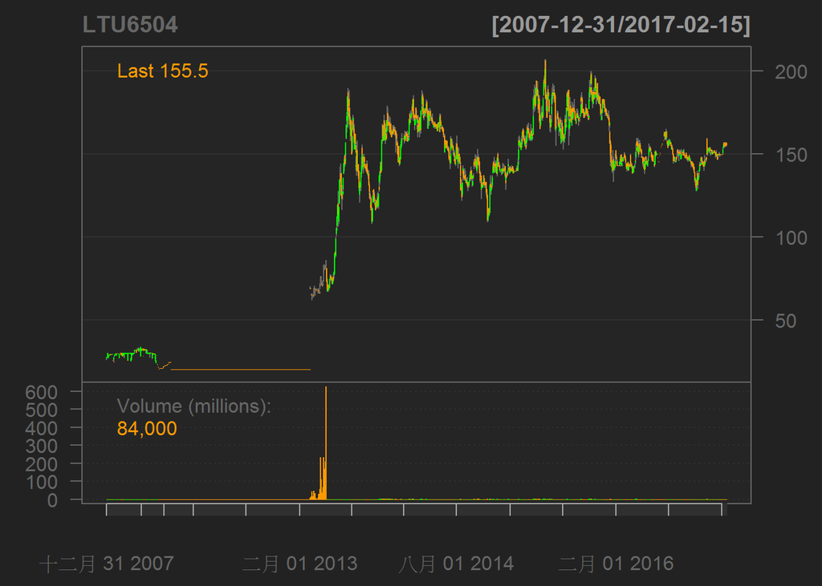

```r
chartSeries(LTU6504)
```

```r
getDividends("6504.TW")
```

```
##                [,1]
## 2011-06-28 0.151515
## 2012-07-17 0.300000
## 2013-05-20 1.500000
## 2014-06-24 2.200000
## 2015-06-18 2.800000
## 2016-07-27 3.900000
```

```r
#获取股息数据
#getDividends函数可以获取上市公司的股息数据。

#获取除权除息数据
#使用getSplits()函数获取上市公司的除权除息数据：
getSplits("6504.TW")
```

```
## [1] NA
```

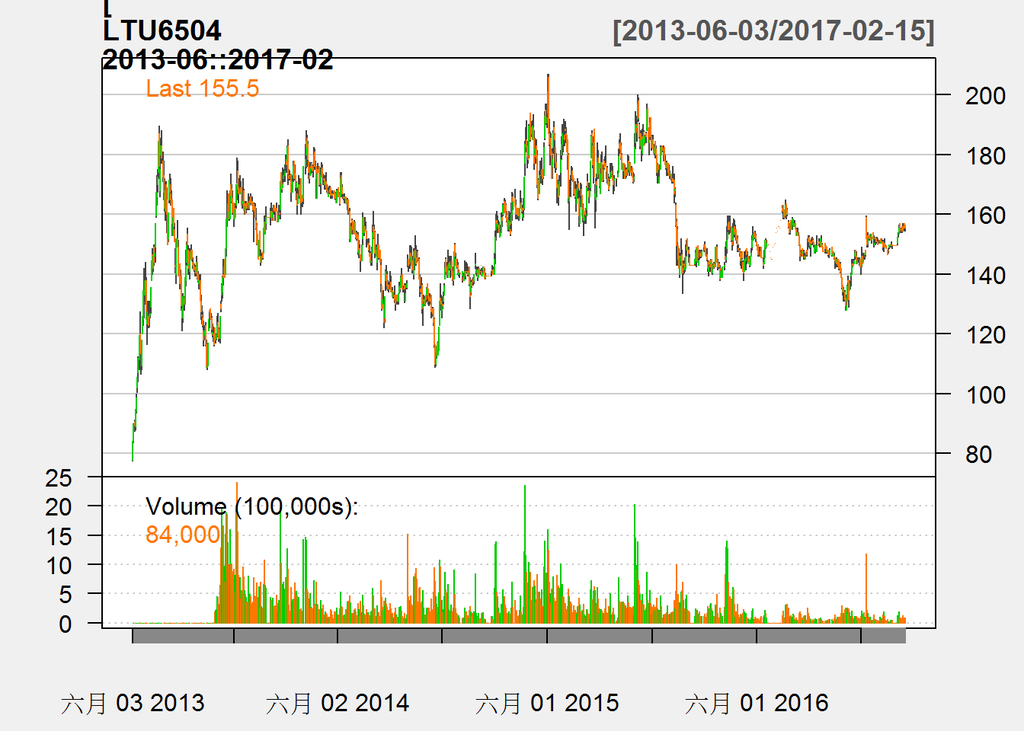

```r
chartSeries(LTU6504["2013-06::2017-02"],theme="white")
```

```r
#我只要看此段區間的資料,同時把版面調成白色
```

## 第5步：R指令劃出LTU6504股價之技術指標

## 5.1 畫出20日平均線(月線)

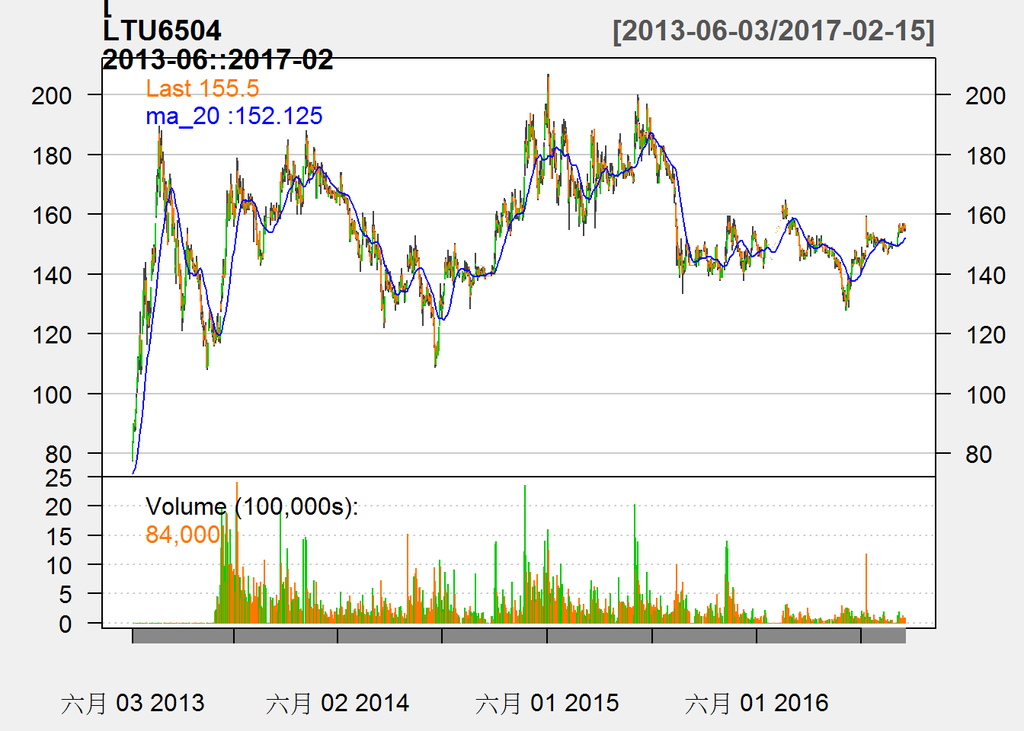

```r
ma_20<-runMean(LTU6504[,4],n=20)

#LTU6504[,4]代表6504股價每日的收盤價(LTU6504.Close)
#因為收盤價放在第四行所以這樣表示。
#runMean這個函數以即n=20表示計算過去20天的平均數。
#因此。ma_20是一個時間序列，每一時間點表示過去20天的收盤平均。

addTA(ma_20,on=1,col="blue")
```

```r
#將20日均線(ma_20)的圖形，用藍色線條加到目前K線圖上
```

## 5.2 畫出60日平均線(季線)

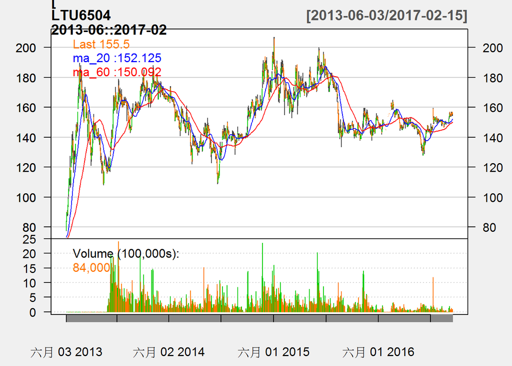

```r
ma_60<-runMean(LTU6504[,4],n=60)


#runMean這個函數以即n=60表示計算過去60天的平均數。
#因此。ma_60是一個時間序列，每一時間點表示過去60天的收盤平均。

addTA(ma_60,on=1,col="red")
```

```r
#將60日均線(ma_60)的圖形，用紅色線條加到目前K線圖上
```